# Modern Data Mining - HW 5

Wendy Deng

Ruolan Li

Kira Nightingale

Due: 11:59Pm, 4/16, 2023

# Overview

For the purpose of predictions, a nonlinear model or a model free approach could be beneficial.

Neural networks are a good way to do prediction because they are capable of learning complex patterns and relationships within data, without requiring explicit programming of rules. They are able to recognize non-linear relationships and make predictions based on those patterns, which can be very difficult to accomplish with traditional statistical models. Neural networks can also be used for a wide range of prediction tasks, including image and speech recognition, natural language processing, and time series forecasting.

Neural networks have been around for several decades, but they have become more popular and widely used in recent years due to several factors. One reason is the increase in available data, which allows for more robust and accurate training of neural networks. Additionally, advancements in hardware technology have made it easier and more cost-effective to train large neural networks. Another reason is the development of new neural network architectures, such as convolutional neural networks (CNNs) and recurrent neural networks (RNNs), which have proven to be very effective for specific tasks. Finally, the rise of deep learning, which is a subfield of machine learning that utilizes deep neural networks with many layers, has further propelled the popularity of neural networks due to their ability to achieve state-of-the-art performance on a wide range of tasks.Neural Network is a natural extension of the linear models.

On a model free side, a binary decision tree is the simplest, still interpretable and often provides insightful information between predictors and responses. To improve the predictive power we would like to aggregate many equations, especially uncorrelated ones. One clever way to have many free samples is to take bootstrap samples. For each bootstrap sample we build a random tree by taking a randomly chosen number of variables to be split at each node. We then take average of all the random bootstrap trees to have our final prediction equation. This is RandomForest.

Ensemble method can be applied broadly: simply take average or weighted average of many different equations. This may beat any single equation in your hand.

All the methods covered can handle both continuous responses as well as categorical response with multiple levels (not limited to binary response.)

## Objectives

- Understand a basic NN
  - Be able to write an architecture (a model)
  - Understand the roles of
    - Hidden layers
    - Neurons
    - Relu activation function
  - Be able to run keras to train and to use a NN.
- Understand trees
  - single tree/displaying/pruning a tree
  - RandomForest
  - Ensemble idea
- R functions/Packages
  - `kears`
  - `tree`, `RandomForest`, `ranger`
- Json data format
- text mining
  - bag of words

Data needed:

- `yelp_review_20k.json`
- `IQ.Full.csv`

# Problem 0: Lectures

Please study all the lectures. Understand the main elements in each lecture and be able to run and compile the lectures

- textmining
- deep learning
- trees
- boosting

# Problem 1: Yelp challenge 2019

**Note:** This problem is rather involved. It covers essentially all the main materials we have done so far in this semester. It could be thought as a guideline for your final project if you want when appropriate.

Yelp has made their data available to public and launched Yelp challenge. [More information](https://www.yelp.com/dataset/). It is unlikely we will win the $5,000 prize posted but we get to use their data for free. We have done a detailed analysis in our lecture. This exercise is designed for you to get hands on the whole process.

**Data needed:** yelp_review_20k.json available in Canvas.

## Goal of the study

The goals are

1. Try to identify important words associated with positive ratings and negative ratings. Collectively we have a sentiment analysis.
2. To predict ratings using different methods.

## JSON data and preprocessing data

1. Load *json* data

The *json* data provided is formatted as newline delimited JSON (ndjson). It is relatively new and useful for streaming.

We use `stream_in()` in the `jsonlite` package to load the JSON data (of ndjson format) as `data.frame`. (For the traditional JSON file, use `fromJSON()` function.)

**Write a brief summary about the data:**

1. Which time period were the reviews collected in this data? **These reviews were collected between 10/19/2004-10/4/2018.**
2. Are ratings (with 5 levels) related to month of the year or days of the week? Only address this through EDA please. **Based on Figure 1, we don’t observe any clear pattern regarding star rating and month. Although there are some months with fewer reviews overall (for example, November), the ratio between the star ratings is more or less consistent across months. The same is true of day of the week, with no particular day seeming to have a different distribution in ratings than any other, as seen in Figure 2.**

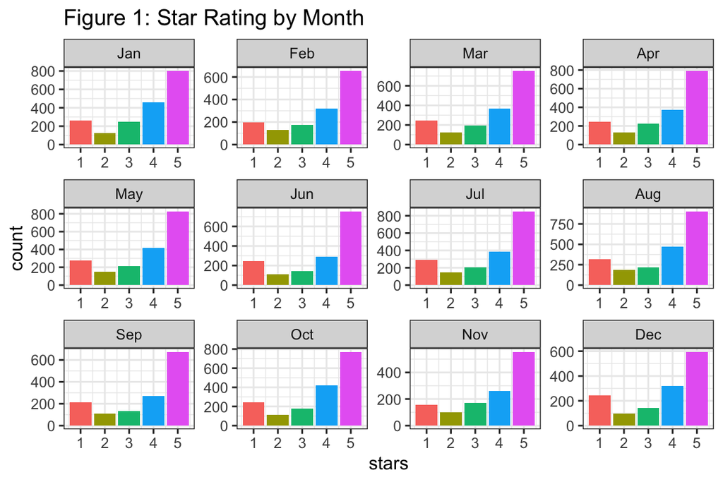

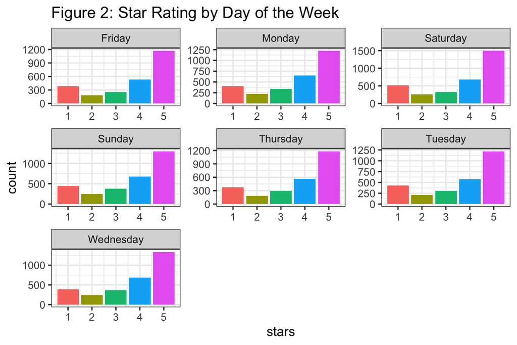

```
##
##        Friday    Monday  Saturday    Sunday  Thursday   Tuesday Wednesday
##   1 0.1299454 0.1354025 0.1732606 0.1531378 0.1282401 0.1463165 0.1336971
##   2 0.1189542 0.1477124 0.1692810 0.1575163 0.1176471 0.1346405 0.1542484
##   3 0.1113586 0.1483296 0.1412027 0.1706013 0.1322940 0.1349666 0.1612472
##   4 0.1216713 0.1487603 0.1554178 0.1542700 0.1294766 0.1320018 0.1584022
##   5 0.1312668 0.1373098 0.1676365 0.1451432 0.1322739 0.1365264 0.1498433
```

```
##
##              1          2          3          4          5          6
##   1 0.08833561 0.06684857 0.08390177 0.08253752 0.09549795 0.08356071
##   2 0.08366013 0.08496732 0.08169935 0.08692810 0.09738562 0.07450980
##   3 0.10957684 0.07884187 0.08775056 0.09933185 0.09487751 0.06280624
##   4 0.10537190 0.07392103 0.08402204 0.08539945 0.09641873 0.06680441
##   5 0.08974933 0.07329902 0.08426589 0.08863026 0.09265891 0.08448970
##
##              7          8          9         10         11         12
##   1 0.09993179 0.10811733 0.07298772 0.08219645 0.05286494 0.08321965
##   2 0.09673203 0.11960784 0.07058824 0.07385621 0.06535948 0.06470588
##   3 0.09175947 0.09710468 0.06013363 0.07928731 0.07527840 0.06325167
##   4 0.08815427 0.10858586 0.06175390 0.09595960 0.06014692 0.07346189
##   5 0.09523277 0.10127574 0.07542525 0.08628021 0.06210833 0.06658460
```

2. Document term matrix (dtm) (bag of words)

Extract document term matrix for texts to keep words appearing at least .5% of the time among all 20000 documents. Go through the similar process of cleansing as we did in the lecture.

1. Briefly explain what does this matrix record? What is the cell number at row 100 and column 405? What does it represent? **The sparsity matrix provides the number of times each word is used in a given review, where rows represent individual reviews and columns represent a word. The cell number for row 100 column 405 is “0”, indicating that review number 100 used the word “event” 0 times.**
2. What is the sparsity of the dtm obtained here? What does that mean? **The sparsity of the dtm after eliminating words that appear in less than 0.5% of reviews is 98%, which tells us that 98% of the cells in our matrix are 0 (i.e., the word is not used in the review).**
3. Set the stars as a two category response variable called rating to be “1” = 5,4 and “0”= 1,2,3. Combine the variable rating with the dtm as a data frame called data2.

## Analyses

Get a training data with 13000 reviews and the 5000 reserved as the testing data. Keep the rest (2000) as our validation data set.

### LASSO

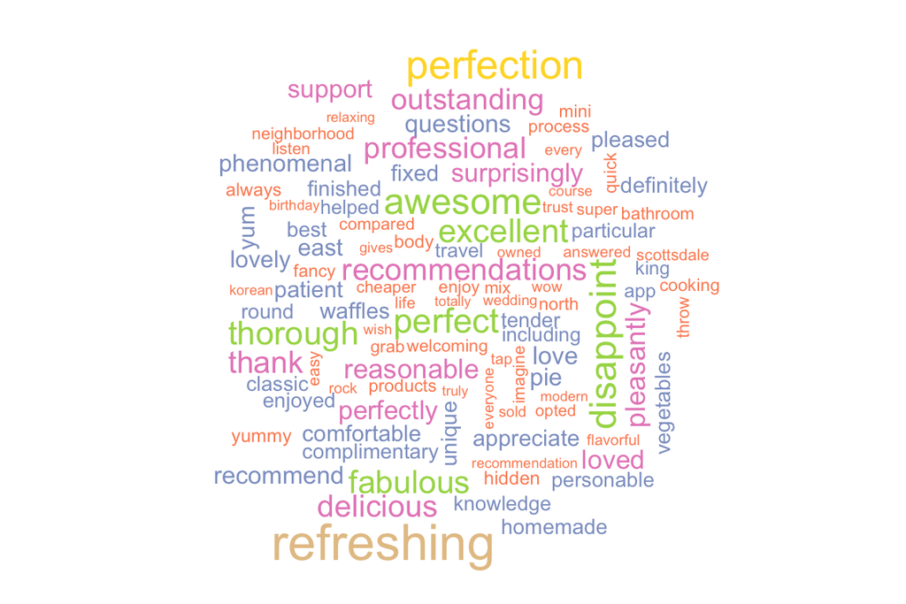

3. Repeat a) and b) above for the bag of negative words.

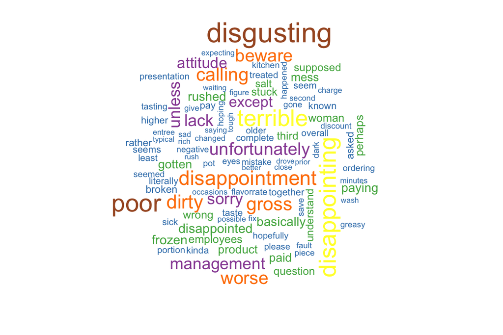

### Neural network

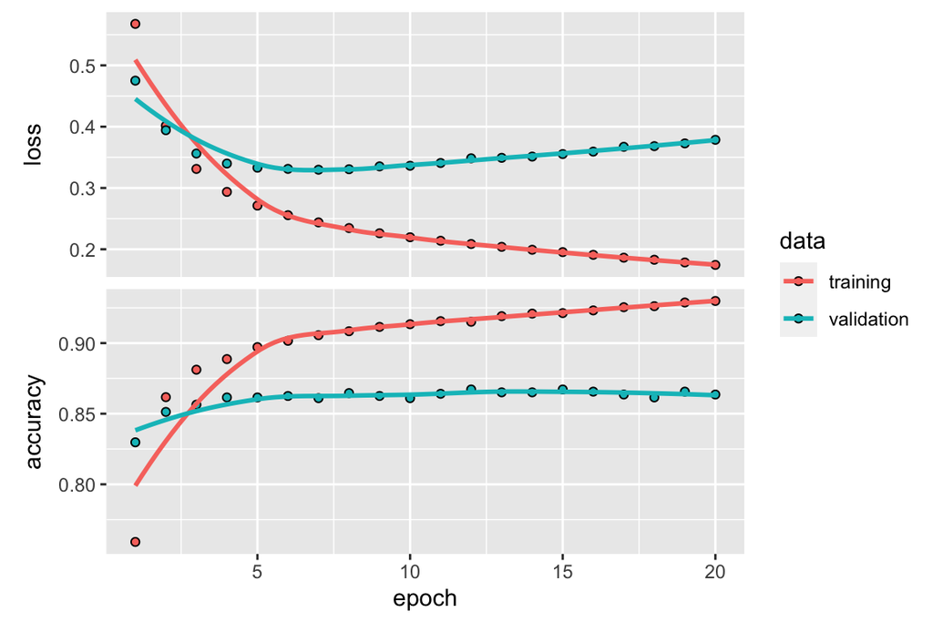

3. Report the testing errors using majority vote. **Our accuracy for this model is 87.9%, which equates to a misclassification error of 12.1%. The loss for this model is 0.32.**

### Random Forest

1. Briefly summarize the method of Random Forest **The structures of the trees are very similar to that of using the whole dataset. To build uncorrelated trees, Random Forest builds trees based on bootstrap samples and variables that are randomly chosen each time. For regression trees, the predicted value is the average of the predicted values each time. For classification trees, the predicted label is based on majority vote.**
2. Now train the data using the training data set by RF and call it `fit.rf`.

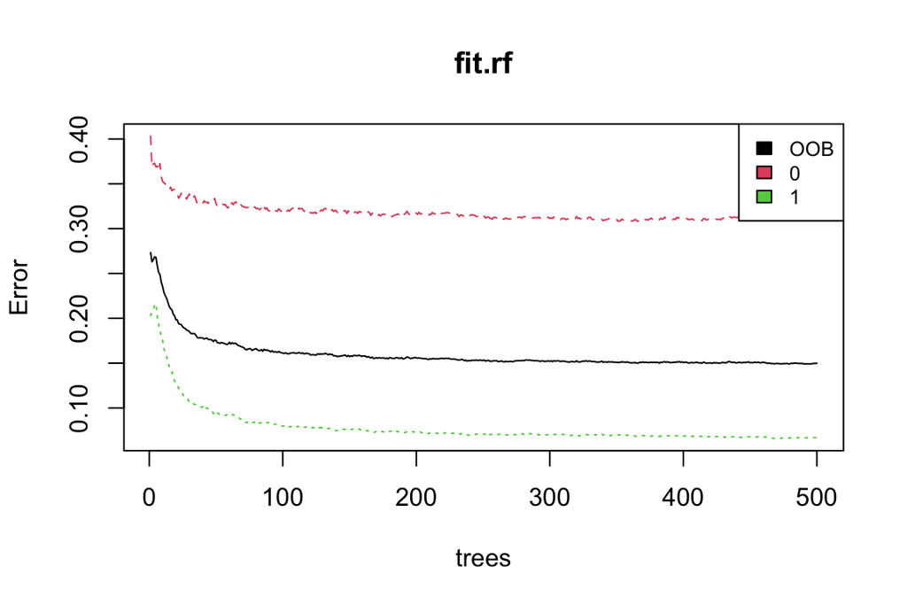

```r
# train the data using RF
#fit.rf <- randomForest(as.factor(rating)~., data2.train, mtry=sqrt(ncol(data2.train)-1), ntree=500)  This would take about 20 mins, I saved it as .rds file
#saveRDS(fit.rf, "fit.rf.rds")
fit.rf <- readRDS("fit.rf.rds")
plot(fit.rf)
legend("topright", colnames(fit.rf$err.rate), col = 1:3, cex=0.8, fill=1:3)
```

a) Explain how you tune the tuning parameters (`mtry` and `ntree`). **I used the default settings for classification trees, where `mtry` is the square root of number of variables and `ntree` is 500.**

2. Get the testing error of majority vote.

```r
predict.rf.y <- predict(fit.rf, newdata=data2.test)
rf.test.err <- mean(data2.test$rating != predict.rf.y)
rf.test.err
```

```
## [1] 0.1416
```

**The testing error is 0.1416.**